# bayesian updating

Vanessa Ferdinand

6/15/2020

## Bayesian updating

```r
bayes_update <- function(prior,likelihood) { # likelihood of the data under each hypothesis
    posterior <- prior*likelihood/sum(prior*likelihood)
    return(posterior)
}
```

Flip a coin with bias $p$ N times. Result is $k$ number of heads.

```r
flip <- function(p,N) {
    k_heads <- rbinom(N,1,p)
    return(k_heads)
}

# example usage:
flip(0.5,1)
```

```
## [1] 1
```

```r
hypotheses <- c(.5,.7,.3)
prior <- rep(1/3,3)
```

Now we’re gonna observe some coin flip(s) and update the prior. Here are a few examples of how we could do that:

### One coin flip

Generate one coin flip, calculate its likelihood under each hypothesis, and update the prior.

```r
# generate one coin flip
N <- 1
flips <- flip(0.5,N)
k <- sum(flips)

# calculate the likelihood of the outcome under each hypothesis
likelihood <- dbinom(k,N,prob=hypotheses)

# update the prior with bayes rule
bayes_update(prior,likelihood)
```

```
## [1] 0.3333333 0.4666667 0.2000000
```

### N coin flips

Now we compute the likelihood of the data given the hypotheses like before, but we need to compute the likelihood of the whole set of coin flips.

Multiply the probabilitiy of each flip

Calculate the likelhood of k heads from N flips:

```r
# generate N coin flips
N <- 100
flips <- flip(0.5,N)
k <- sum(flips)

# calculate the likelihood of the outcome under each hypothesis
likelihood <- dbinom(k,N,prob=hypotheses)

# update the prior with bayes rule
posterior <- bayes_update(prior,likelihood)

print(flips)
```

```
##   [1] 0 0 0 1 1 0 0 1 0 1 1 0 1 1 0 1 0 1 1 0 0 1 1 1 1 0 0 0 1 1 0 0 1 0 1
##  [36] 0 1 0 0 0 0 1 1 1 1 1 0 0 1 0 1 1 0 0 1 1 0 1 1 1 1 1 1 0 1 1 0 0 0 0
##  [71] 0 1 1 0 0 1 0 1 1 1 1 1 1 1 0 0 1 0 1 1 1 0 1 1 0 0 1 1 1 1
```

```r
print(posterior)
```

```
## [1] 9.419462e-01 5.805343e-02 4.094048e-07
```

### N coin flips, but sequentially

Now take the same sequence of flips generated above, but update the hypotheses on the basis of each one.

```r
flips_to_history <- function(flips,prior) {
    history <- data.frame(t(prior))
    names(history) <- c("h1","h2","h3")

    for (f in flips) {
        # get likelihood of the current flip under each hypothesis
        likelihood <- dbinom(f,1,prob=hypotheses)

        # update the prior on the basis of the current flip (posterior = the new prior)
        prior <- bayes_update(prior,likelihood)

        # save the posterior to the history dataframe
        history <- rbind(history,prior)
    }
    return(history)
}

history <- flips_to_history(flips,prior)
```

Plot the learning trajectory

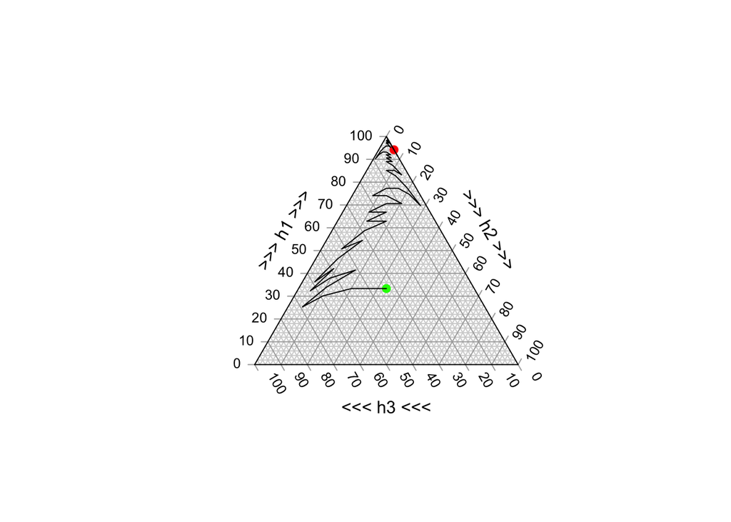

```r
# dev.new(5,5) # comment out for knitting into markdown
TernaryPlot(alab='>>> h1 >>>', blab='>>> h2 >>>', clab='<<< h3 <<<')
TernaryPoints(head(history,1),col="green",pch=19)
TernaryPoints(tail(history,1),col="red",pch=19)
TernaryLines(history)
```

**Take home message 1**

Updating one by one yields the same answer as batch updating does. Compare the posterior from the section above to the final update in the current section:

```r
print(posterior)
```

```
## [1] 9.419462e-01 5.805343e-02 4.094048e-07
```

```r
print(tail(history,1))
```

```
##            h1         h2           h3
## 101 0.9419462 0.05805343 4.094048e-07
```

**Take home message 2**

The order in which the flips come in do matter - they determine the exact learning trajectory that is taken. Even though it always ends up in the same place.

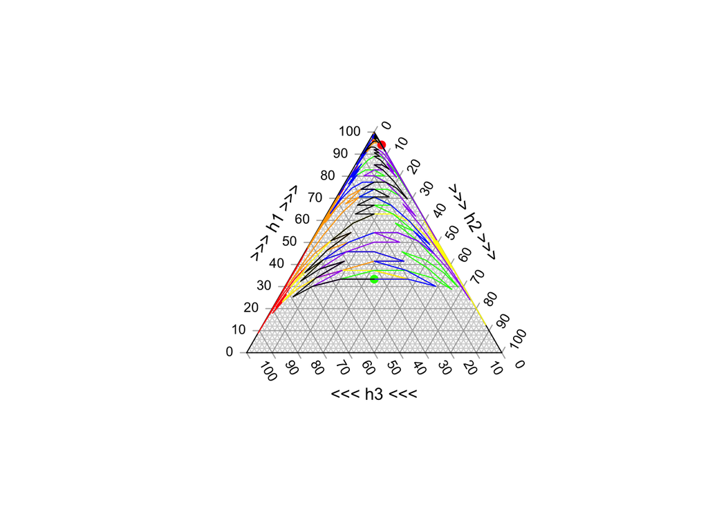

```r
#dev.new(5,5)
TernaryPlot(alab='>>> h1 >>>', blab='>>> h2 >>>', clab='<<< h3 <<<')
TernaryPoints(head(history,1),col="green",pch=19)
TernaryPoints(tail(history,1),col="red",pch=19)
colorz <- c("red","orange","yellow","green","blue","purple")
for (i in 1:6) {
    flips_shuffled <- sample(flips)
    df <- flips_to_history(flips_shuffled,prior)
    TernaryLines(df,col=colorz[i])
}
TernaryLines(history) # plot that original history in black on top of the others
```

## More data = more learnin’

The prior is updated more when there’s more data.

```r
# take two different likelihoods:
a <- dbinom(0,1,prob=hypotheses) # 0 heads from 1 flip
lower_differential_fitness <- a/sum(a)

f <- dbinom(0,3,prob=hypotheses) # 0 heads from 3 flips
higher_differential_fitness <- f/sum(f)

# update the a uniform prior with those likelihoods:
uniform_prior <- rep(1/3,3)

update_a <- bayes_update(uniform_prior,lower_differential_fitness)
update_f <- bayes_update(uniform_prior,higher_differential_fitness)

# entropy of uniform prior     # 1.584963
#H(uniform_prior,2)

# entropy after updating to a  # 1.565596
#H(update_a,2)

# entropy after updating to f  # 1.427757
#H(update_f,2)

# 1.584963-1.565596 = 0.019367 bits
# 1.584963-1.427757 = 0.157206 bits

# The strong update (f) made the prior change by more bits than the weak update (a) did.
```

That’s always the case when the prior is uniform (i.e. it contains no information of its own). But when the prior contains information, it can be in line with the fitness values (meaning fitness favors the hypothesis with maximum a priori probability), or in opposition to it (meaning fitness favors a hypothesis that isn’t max one).

## The dynamics of uncertainty

As the number of flips grows (i.e. as the amount of incoming data grows), differentiation among hypotheses grows (i.e. the difference among their relative fitness values grows)

1 flips:  
H  
T

2 flips:  
HH  
HT  
TH  
TT

3 flips:  
HHH  
HHT  
HTH  
HTT  
THH  
THT  
TTH  
TTT

Here’s what the likelihood of each data type are, under the hypotheses:

```r
require(entropy)
H <- function(X,base) {
  X <- X[X != 0 ] # remove all zeros
  if (missing(base)) { base = 2 } # make it so you don't have to supply argument for base=2
  return(-sum(X*log(X,base)))
}

KL <- function(P,Q,base) {  # doesn't handle zeros yet
    if (missing(base)) { base = 2 }
    return((-sum(Q*log(P,base))) - H(Q,base))
}
```

```r
Q <- c(.5,.3,.2)
P <- c(.2,.5,.3)
P2 <- c(.2,.3,.5)
KL.empirical(Q,Q)  # 0
```

```
## [1] 0
```

```r
KL.empirical(P,Q)  # 0.1937942
```

```
## [1] 0.1937942
```

```r
KL.empirical(Q,P)  # 0.2238047
```

```
## [1] 0.2238047
```

```r
KL.plugin(Q,Q)     # 0
```

```
## [1] 0
```

```r
KL.plugin(P,Q)     # 0.1937942
```

```
## [1] 0.1937942
```

```r
KL.plugin(Q,P)     # 0.2238047
```

```
## [1] 0.2238047
```

```r
KL.empirical(P2,Q)  # 0.2748872  # if the distributions are symmetrical, THEN kl is sym
```

```
## [1] 0.2748872
```

```r
KL.empirical(Q,P2)  # 0.2748872
```

```
## [1] 0.2748872
```

```r
KL(Q,Q)            # 0
```

```
## [1] 0
```

```r
KL(P,Q)            # 0.3228819
```

```
## [1] 0.3228819
```

```r
KL(Q,P)            # 0.2795859
```

```
## [1] 0.2795859
```

```r
# 1 flip                          # likelihoods        # H(likelihoods)
a <- dbinom(0,1,prob=hypotheses)  # 0.5 0.4 0.6        # 1.565596
b <- dbinom(1,1,prob=hypotheses)  # 0.5 0.6 0.4        # 1.565596

# 2 flips
c  <- dbinom(0,2,prob=hypotheses)  # 0.25 0.16 0.36    # 1.510764
d  <- dbinom(1,2,prob=hypotheses)  # 0.50 0.48 0.48    # 1.584693
e  <- dbinom(2,2,prob=hypotheses)  # 0.25 0.36 0.16    # 1.510764

f  <- dbinom(0,3,prob=hypotheses)  # 0.125 0.064 0.216 # 1.427757
g  <- dbinom(1,3,prob=hypotheses)  # 0.375 0.288 0.432 # 1.565592
h  <- dbinom(2,3,prob=hypotheses)  # 0.375 0.432 0.288 # 1.565592
i  <- dbinom(3,3,prob=hypotheses)  # 0.125 0.216 0.064 # 1.427757

# mean H(differential fitness) of all 1 flip outcomes: # 1.565596
mean(c(1.565596,1.565596))
```

```
## [1] 1.565596
```

```r
# mean H(differential fitness) of all 2 flip outcomes: # 1.547728
mean(c(1.510764,1.584693,1.584693,1.510764))
```

```
## [1] 1.547728
```

```r
# mean H(differential fitness) of all 3 flip outcomes: # 1.531133
mean(c(1.427757,1.427757,1.565592,1.565592,1.565592,1.565592,1.565592,1.565592))
```

```
## [1] 1.531133
```

```r
x <- a
a/sum(a)
```

```
## [1] 0.3333333 0.2000000 0.4666667
```

The strength of differential fitness goes up, on average, as more data comes in.

What is the average strength differential fitness, across all outcomes of N flips? (Need to do a weighted average using the probability of the outcome if calculating things where order doesn’t matter)

I want to reduce the strength of the differential fitness to one number. So I’m gonna use the entropy of the distribution of fitness values. The likelhood values are not a probability distribution that sums to one. But since they’re a differential fitness, we can convert those fitness values to relative fitness - and make it relative to the total fitness (so divide by total fitness and now we’ve got a proper distribution over fitness values that sum to one). I could also use the KL divergence from the maxent (uniform) distribution.

# plots for slides

```r
# Use these flips

# 50/50
f1 <- c(0, 1, 1, 0, 0, 1, 0, 1, 1, 0, 1, 1, 1, 1, 0, 1, 0, 0, 0, 1, 0, 0, 1, 0, 1, 0, 0, 1, 0, 1, 0, 1, 0, 0, 1, 1, 0, 0, 0, 0, 1, 0, 0, 0, 1, 1, 0, 1, 0, 1, 1, 1, 0, 0, 1, 1, 1, 0, 0, 1, 1, 0, 0, 0, 1, 0, 1, 0, 0, 1, 1, 0, 1, 1, 1, 1, 1, 1, 0, 1, 0, 0, 0, 1, 0, 1, 0, 0, 1, 0, 0, 1, 0, 1, 0, 0, 1, 1, 1, 1)

# 70/30
f2 <- c(0, 1, 0, 0, 1, 0, 0, 1, 0, 0, 0, 1, 0, 0, 0, 1, 1, 0, 0, 0, 1, 0, 1, 0, 1, 0, 0, 1, 0, 0, 1, 1, 0, 0, 0, 0, 0, 0, 0, 0, 0, 1, 0, 0, 0, 0, 1, 0, 1, 0, 0, 0, 0, 0, 0, 0, 0, 0, 1, 0, 0, 1, 1, 0, 0, 1, 0, 1, 0, 0, 0, 0, 1, 1, 1, 0, 0, 0, 0, 1, 0, 0, 0, 0, 0, 0, 1, 0, 1, 0, 0, 1, 0, 0, 1, 0, 0, 1, 1, 0)

f3smooth <- c(1, 1, 1, 1, 1, 1, 0, 1, 1, 1, 0, 1, 1, 1, 1, 1, 0, 0, 1, 1, 0, 1, 1, 1, 1, 1, 0, 1, 1, 1, 0, 1, 1, 0, 0, 0, 1, 1, 1, 1, 1, 1, 1, 0, 1, 1, 0, 1, 1, 1, 1, 1, 1, 1, 0, 1, 0, 1, 0, 1, 1, 0, 1, 0, 1, 1, 0, 1, 1, 0, 0, 1, 0, 1, 1, 1, 0, 1, 0, 1, 1, 1, 1, 1, 0, 1, 1, 1, 0, 0, 1, 1, 1, 0, 0, 0, 1, 0, 1, 1)

# generated this way:
f1 <- sample(c(rep(0,70),rep(1,30)))
```

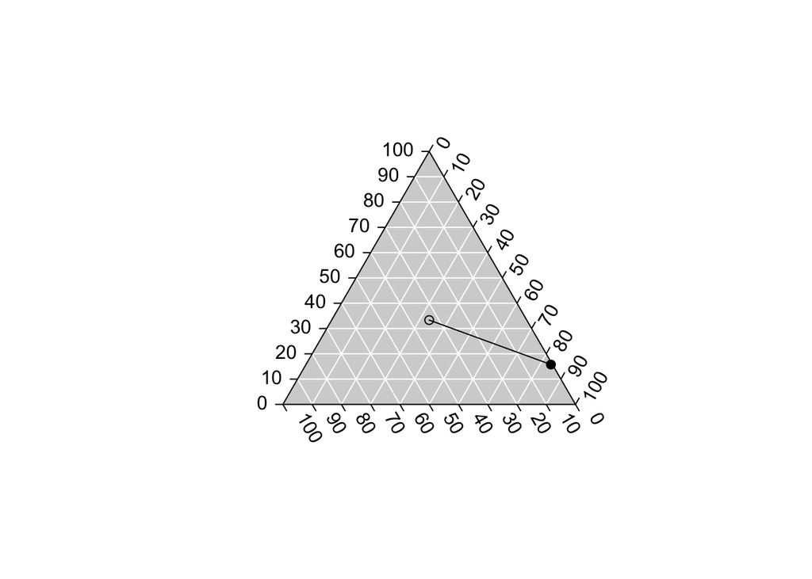

```r
# 50/50 history (from 50/50 source AND 50/50 outcome)
flips <- f1[0:10]
hypotheses <- c(.5,.3,.7)
history <- flips_to_history(flips,prior)
h2 <- rbind(head(history,1),tail(history,1))

#flips <- f1
# dev.new(5,5) # comment out for knitting into markdown
TernaryPlot(axis.cex = 1, grid.minor.col = NA, col = "lightgrey", grid.col = "white",
            ticks.col = "black")
TernaryLines(h2)
TernaryPoints(head(history,1),col="black",pch=1)
TernaryPoints(tail(history,1),col="black",pch=19)
```

```r
# alab='>>> h1 >>>', blab='>>> h2 >>>', clab='<<< h3 <<<'
```

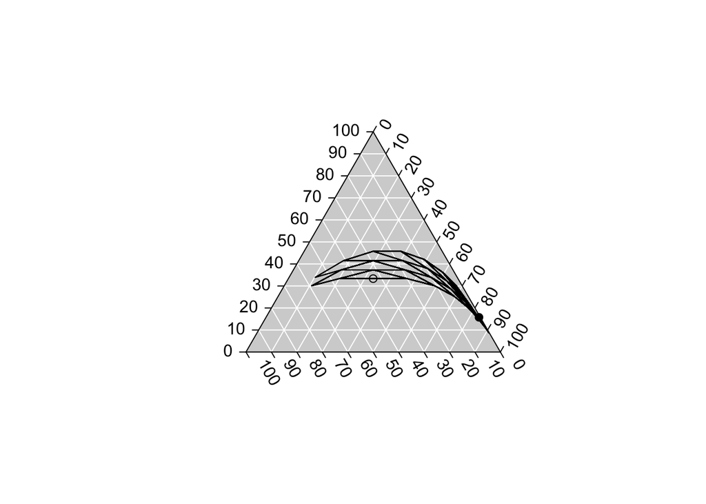

```r
first <- f2[0:10]

TernaryPlot(axis.cex = 1, grid.minor.col = NA, col = "lightgrey", grid.col = "white",
            ticks.col = "black")
TernaryPoints(head(history,1),col="black",pch=1)  # plot the start point
TernaryPoints(tail(history,1),col="black",pch=19) # plot the end point
# plot lattice
for (i in 1:200) {
    flips_shuffled <- sample(first)
    df <- flips_to_history(flips_shuffled,prior)
    TernaryLines(df,col="black")
}
```

```r
#df <- flips_to_history(first,prior) # then plot the original trajectory
#TernaryLines(df)
```

There are 2**10 binary sequences of length 10. There are 252 50/50 sequences of length 10. There are 120 70/30 sequences of length 10.

Here is the math for this:

```r
2**10        # 1024
```

```
## [1] 1024
```

```r
choose(10,5) # 252
```

```
## [1] 252
```

```r
choose(10,7) # 120
```

```
## [1] 120
```

K so obviously there are other sequences (like a 55/45 one) that will lead to the 50/50 hypothesis winning out over the 70/30 hypothesis. How can you tell which basin of attraction any given sequence is in?

Well just compute the likelhood of your sequence under all of the hypotheses being entertained. And see which one has the higher likelihood. That should be the one that wins out eventually! (This is when the “learner is not entertaining all possible hypotheses” thing gets interesting.)

Examples:

A 5:5 sequence has:  
a likelihood of $.5^{10} = 0.0009765625$ under the 50/50 hypothesis.  
a likelihood of $.7^{5} \times .3^{5} = 0.0004084101$ under the 70/30

A 6:4 sequence has:  
a likelihood of $.5^{6} \times .5^{4} = 0.0009765625$ under the 50/50 hypothesis.  
a likelihood of $.7^{6} \times .3^{4} = 0.0009529569$ under the 70/30

Interesting, the 6:4 should go to the 50/50 hypothesis.

```r
# a 5:5 sequence
.5^10
```

```
## [1] 0.0009765625
```

```r
.3^5 * .7^5
```

```
## [1] 0.0004084101
```

```r
# a 6:4 sequence
.5^6 * .5^4
```

```
## [1] 0.0009765625
```

```r
.7^6 * .3^4
```

```
## [1] 0.0009529569
```

```r
# to find where the likelihoods are the same, do a search
.7^6.03 * .3^3.97
```

```
## [1] 0.0009774905
```

Check that:

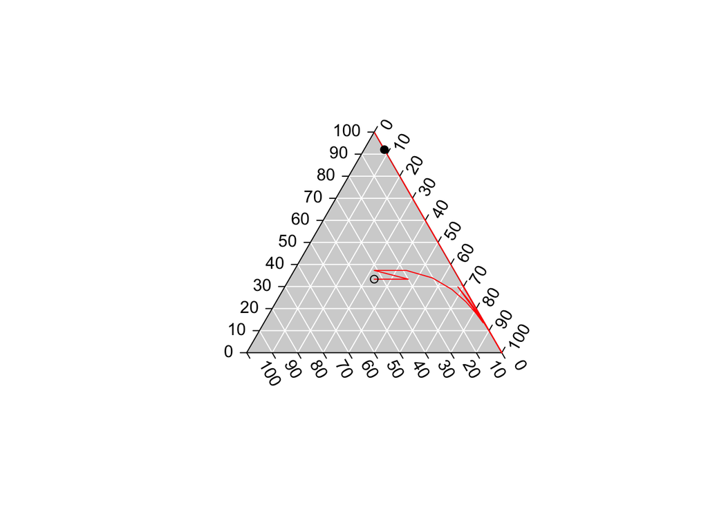

```r
# 60/40 history (empirically 60/40)
flips <- sample(c(rep(0,600),rep(1,400)))
hypotheses <- c(.5,.3,.7)
history <- flips_to_history(flips,prior)

TernaryPlot(axis.cex = 1, grid.minor.col = NA, col = "lightgrey", grid.col = "white",
            ticks.col = "black")
TernaryLines(history,col="red")
TernaryPoints(head(history,1),col="black",pch=1)
TernaryPoints(tail(history,1),col="black",pch=19)
```

Yep.

So you can solve the basins of attraction by searcing all of the edge cases and finding the pair of sequences when it flips.

Also there’s probably some easy math for this since the equations for calculating the likelihoods was so easy in the first place.

Some replicator dynamics plots

```r
replicator_update <- function(population,fitness) { # likelihood of the data under each hypothesis
    next_population <- population*fitness/sum(population*fitness)
    return(next_population)
}

# example usage:
unipop <- c(rep(1/3,3))
fitness <- c(2,4,6)
replicator_update(unipop,fitness)
```

```
## [1] 0.1666667 0.3333333 0.5000000
```

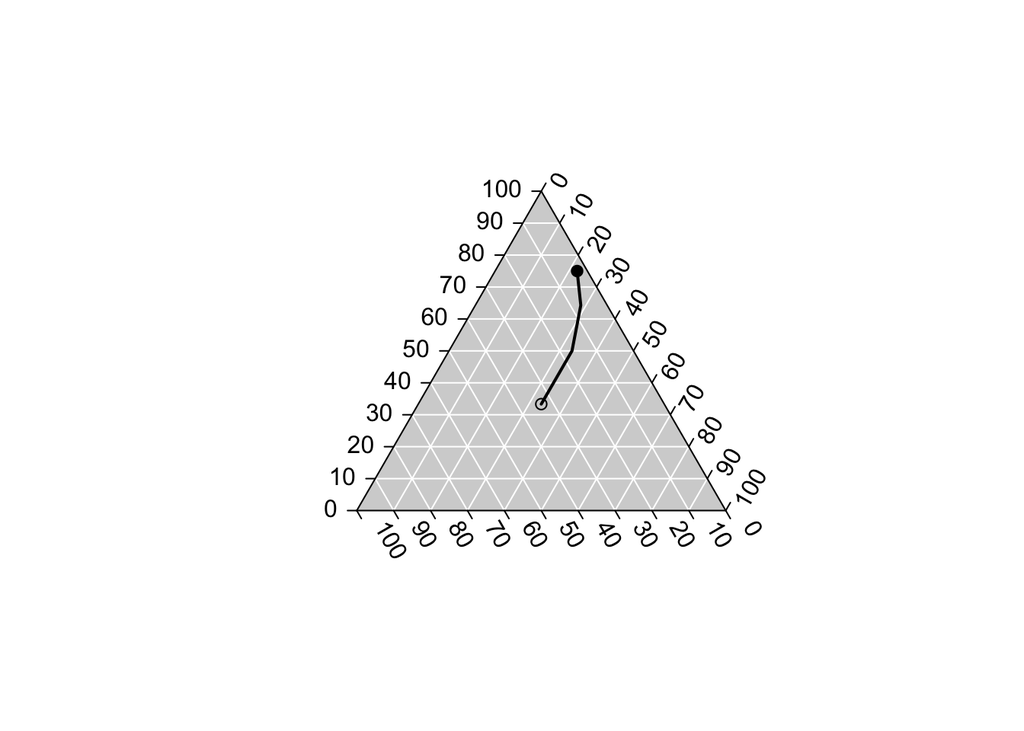

```r
replicator_history <- function(init_pop,fitness,generations) {
    history <- data.frame(t(init_pop))
    names(history) <- c("a1","a2","a3")

    pop <- init_pop
    for (g in 1:generations) {
        pop <- replicator_update(pop,fitness)
        history <- rbind(history,pop)
    }
    return(history)
}

init_pop <- c(rep(1/3,3))
fitness <- c(6,4,2)
history <- replicator_history(init_pop,fitness,10)

TernaryPlot(axis.cex = 1, grid.minor.col = NA, col = "lightgrey", grid.col = "white",
            ticks.col = "black")
TernaryLines(history[1:4,],col="black",lwd=2)
TernaryPoints(history[1,],col="black",pch=1)
TernaryPoints(history[4,],col="black",pch=19)
```